Universidad El Bosque

Diseño de Experimentos

Sesión 1 de 2 · 90 min

# Diseños anidados

Reconocer el anidado y probar bien: el modelo, la tabla, el factorial que engaña, las esperanzas y el denominador del F

Factor anidadoSubíndice muertoANOVA de dos etapasFactorial incorrectoEsperanzas de los cuadrados mediosDenominador del F

**Javier Mauricio Sierra**

Universidad El Bosque

Diseño de Experimentos

Capítulo 9 · Diseños anidados

Cuándo un factor está anidado

El modelo y la tabla de dos etapas

El análisis factorial incorrecto

Las esperanzas de los cuadrados medios

Elegir el denominador del F

Cierre y práctica

Hoja de ruta

## Lo que vamos a construir hoy

Objetivo de la sesión

Reconocer un factor anidado con una pregunta sobre el protocolo, escribir su modelo y su tabla ANOVA, ver por qué el análisis factorial engaña y elegir el denominador de cada F leyendo las esperanzas de los cuadrados medios.

Factor anidadoSubíndice muertoANOVA de dos etapasFactorial incorrectoEsperanzas de los cuadrados mediosDenominador del F

2 / 42

Universidad El Bosque

Diseño de Experimentos

Capítulo 9 · Diseños anidados

Cuándo un factor está anidado

El modelo y la tabla de dos etapas

El análisis factorial incorrecto

Las esperanzas de los cuadrados medios

Elegir el denominador del F

Cierre y práctica

01

## Cuándo un factor está anidado

Los ocho capítulos anteriores cruzaban todos sus factores. Este no.

Leer en el material: 9.1 Cuándo un factor está anidado y no cruzado

3 / 42

Cuándo un factor está anidado

## Hasta ahora, el «nivel 2» de un factor significaba lo mismo bajo cada nivel del otro

- Capítulo 7: la temperatura alta era la misma temperatura para los tres materiales de la batería
- Capítulo 6: el lote 1 era el mismo lote para los cinco operarios
- Por eso tenía sentido preguntar «¿el efecto de \(A\) depende del nivel de \(B\)?»: la **interacción**

**Interpretación.** Una interacción solo se puede formular si los niveles de \(B\) significan lo mismo dentro de cada nivel de \(A\). Este capítulo estudia los diseños donde eso no pasa.

Fuente: módulo 9.1, sobre los ejemplos de los capítulos 6 y 7

Capítulo 9 · Diseños anidadosDiseño de Experimentos · UnBosque4 / 42

Cuándo un factor está anidado

## Un factor anidado aparece bajo un único nivel del otro

Factor anidado (jerárquico)

El factor \(B\) está **anidado** dentro de \(A\) cuando cada nivel de \(B\) aparece bajo **un único** nivel de \(A\). Se escribe \(B(A)\) y se lee «\(B\) dentro de \(A\)». Las etiquetas «lote 1», «lote 2»… son números de orden: no significan nada fuera de su padre.

Consecuencia inmediata: **no puede existir la interacción \(AB\)**. No hay nada que cruzar.

Capítulo 9 · Diseños anidadosDiseño de Experimentos · UnBosque5 / 42

Cuándo un factor está anidado

## Tres proveedores, cuatro barriles de cada uno y tres determinaciones por barril: 36 datos

Dato · Montgomery (2017), ejemplo 14.1

Una empresa compra materia prima en barriles a tres proveedores y quiere saber si la **pureza** varía entre ellos. Respuesta codificada: \(y = \text{pureza} - 93\).

1Proveedoretapa 1: \(a = 3\)

→

2Lote dentro del proveedoretapa 2: \(b = 4\) barriles propios de cada uno, 12 distintos

→

3Determinación\(n = 3\) por barril: \(3 \times 4 \times 3 = 36\)

**Interpretación.** Es el anidado de dos etapas que conduce el capítulo: el lote 1 del proveedor 1 y el del proveedor 2 son barriles distintos.

Fuente: Montgomery (2017), ejemplo 14.1, Tabla 14.3 y figura 14.1 · módulo 9.1

Capítulo 9 · Diseños anidadosDiseño de Experimentos · UnBosque6 / 42

Cuándo un factor está anidado

## Si las etiquetas se pueden renumerar sin perder nada, el factor está anidado

#### Anidado: doce barriles, ninguna columna común

| Proveedor | Lotes |
| --- | --- |
| 1 | 1 · 2 · 3 · 4 |
| 2 | 5 · 6 · 7 · 8 |
| 3 | 9 · 10 · 11 · 12 |

#### Cruzado: si el «lote» fuera un día de recepción

|  | Día 1 | Día 2 | Día 3 | Día 4 |
| --- | --- | --- | --- | --- |
| Prov. 1 | \(n = 3\) | \(n = 3\) | \(n = 3\) | \(n = 3\) |
| Prov. 2 | \(n = 3\) | \(n = 3\) | \(n = 3\) | \(n = 3\) |
| Prov. 3 | \(n = 3\) | \(n = 3\) | \(n = 3\) | \(n = 3\) |

**Interpretación.** Decide el protocolo, no los números: ¿el «lote 1» de un proveedor es el mismo objeto que el de otro?

Fuente: Montgomery (2017), p. 619 y figuras 14.1 y 14.2 · módulo 9.1

Capítulo 9 · Diseños anidadosDiseño de Experimentos · UnBosque7 / 42

Pregunta para la clase

## ¿Cruzado o anidado?

1. **El lote:** cinco lotes de materia prima, y cada lote pasa por los cinco operarios.
2. **La colada:** dos químicas de aleación, y tres coladas de cada química.
3. **El operario:** cuatro máquinas, y en cada una trabajan tres operarios distintos.
4. **La disposición:** tres dispositivos de sujeción, cada uno probado con las dos disposiciones.

Cruzado · anidado · anidado · cruzado

Siempre la misma pregunta: ¿el nivel 1 bajo un padre es el **mismo objeto** que el nivel 1 bajo otro? En 1 y 4, sí; en 2 y 3, no.

Fuente: Montgomery (2017), Tabla 4.9, problemas 14.2 y 14.5 y ejemplo 14.2 · módulos 9.1, 9.5, 9.9 y 9.10

Capítulo 9 · Diseños anidadosDiseño de Experimentos · UnBosque8 / 42

Cuándo un factor está anidado

## Renumerar los lotes dentro de su proceso no mueve ninguna suma de cuadrados

Dato · Montgomery (2017), problema 14.1

Propelente de cohete: **tres procesos**, **cuatro lotes** al azar de cada uno y **tres determinaciones** de la velocidad de combustión por lote. El producto del capítulo 6, en otro experimento.

Dato · simulación del curso, semilla 2026

Se barajan los lotes dentro de cada proceso 200 veces. Rango de \(SS_{\text{procesos}}\): **0**. Rango de \(SS_{\text{lotes(proceso)}}\): **0**.

**Dato.** No es «casi cero»: es cero exacto en las 200 barajas.

Fuente: Montgomery (2017), problema 14.1; simulación del curso con `set.seed(2026)`, 200 barajas · módulo 9.1

Capítulo 9 · Diseños anidadosDiseño de Experimentos · UnBosque9 / 42

Pregunta para la clase

## Renumerar los envases no cambia el ANOVA anidado. ¿Qué se concluye?

Tres marcas de adhesivo, cuatro envases distintos de cada marca, dos determinaciones por envase. Un analista renumera al azar los envases dentro de cada marca: las tres sumas de cuadrados salen idénticas.

1. Que el programa calcula mal.
2. Que no hay interacción marca × envase, porque su suma de cuadrados sale cero.
3. Nada sobre la estructura.
4. Que las tres marcas son equivalentes.

3 · Nada sobre la estructura

El ANOVA anidado daría idéntico con **cualquier** conjunto de datos, también con envases cruzados: renumerar dentro del padre solo cambia el nombre de las celdas. Que estén anidados lo dice el protocolo.

Fuente: autoevaluación del módulo 9.12, pregunta 1 · módulo 9.1

Capítulo 9 · Diseños anidadosDiseño de Experimentos · UnBosque10 / 42

Cuándo un factor está anidado

## En el cuadro latino del capítulo 6, renumerar los lotes lo mueve todo

Dato · capítulo 6, Montgomery (2017), Tablas 4.9 y 4.12

El propelente como cuadro latino: cinco lotes de materia prima **cruzados** con cinco operarios. \(SS_{\text{lotes}}\) real: **68.00**.

Dato · simulación del curso, semilla 2026

200 renumeraciones de los lotes dentro de cada columna: \(SS_{\text{lotes}}\) se pasea entre **10.40** y **288.00**.

**Interpretación.** Allí el nombre del lote es información y cambiarlo destruye el diseño. El mismo producto, otro experimento, otro papel para el lote: decide cómo se recogieron los datos.

Fuente: Montgomery (2017), Tablas 4.9 (datos) y 4.12 (\(SS = 68\)); simulación del curso con `set.seed(2026)`, 200 barajas · módulo 9.1

Capítulo 9 · Diseños anidadosDiseño de Experimentos · UnBosque11 / 42

Cuándo un factor está anidado

## Con \(\sigma^2_\beta = \sigma^2\), el factorial da una interacción falsa el 71.9 % de las veces

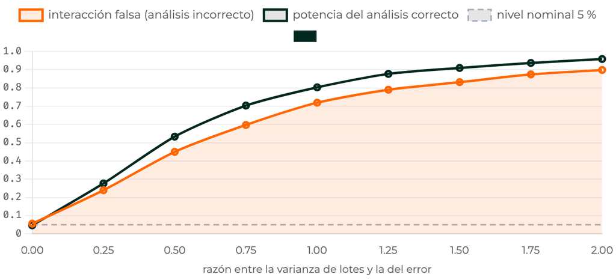

Tasa de interacción falsa del análisis factorial y potencia del análisis anidado, frente a la razón entre la varianza de lotes y la del error

Dato · simulación del curso, semilla 2026

Datos anidados de verdad, \(a = 3\), \(b = 4\), \(n = 3\), sin ninguna interacción:

- Interacción «significativa»: **71.9 %**
- El anidado detecta los lotes: **80.3 %**

**Interpretación.** La interacción sale con su suma de cuadrados y su \(p\), pero no significa lo que su nombre dice (sección 3).

Fuente: simulación del curso, precálculo del capítulo, `set.seed(2026)`, 2000 réplicas por punto · módulo 9.1

Capítulo 9 · Diseños anidadosDiseño de Experimentos · UnBosque12 / 42

Universidad El Bosque

Diseño de Experimentos

Capítulo 9 · Diseños anidados

Cuándo un factor está anidado

El modelo y la tabla de dos etapas

El análisis factorial incorrecto

Las esperanzas de los cuadrados medios

Elegir el denominador del F

Cierre y práctica

02

## El modelo y la tabla de dos etapas

Un anidado de dos etapas es un DCA con una etapa más de muestreo.

Leer en el material: 9.2 El anidado de dos etapas: modelo y ANOVA

13 / 42

El modelo y la tabla de dos etapas

## El modelo de dos etapas es el del DCA con un término más: el lote dentro del proveedor

$$y_{ijk} = \mu + \tau_i + \beta_{j(i)} + \varepsilon_{(ij)k}$$

- \(\tau_i\): el proveedor, \(i = 1, \dots, a\)
- \(\beta_{j(i)}\): el lote \(j\) **dentro del** proveedor \(i\). El \(i\) entre paréntesis va **muerto**: identifica la celda, no aporta un efecto
- \(\varepsilon_{(ij)k}\): la determinación \(k\), anidada en la pareja proveedor-lote

**Interpretación.** Con \(b = 1\), \(\beta_{j(i)}\) se confunde con \(\tau_i\) y queda el modelo de efectos del capítulo 2: un anidado no es un diseño nuevo.

Fuente: Montgomery (2017), ec. 14.1 · módulo 9.2

Capítulo 9 · Diseños anidadosDiseño de Experimentos · UnBosque14 / 42

El modelo y la tabla de dos etapas

## Cada observación es la suma de cuatro trozos, y se comprueba fila a fila

$$y_{ijk} = \bar y_{\cdots} + \underbrace{(\bar y_{i\cdots} - \bar y_{\cdots})}_{\text{proveedor}} + \underbrace{(\bar y_{ij\cdot} - \bar y_{i\cdots})}_{\text{lote dentro}} + \underbrace{(y_{ijk} - \bar y_{ij\cdot})}_{\text{residuo}}$$

| \(y\) | media | proveedor | lote | residuo | suma |
| --- | --- | --- | --- | --- | --- |
| 1 | 0.361111 | −0.777778 | 0.416667 | 1 | 1 |
| −1 | 0.361111 | −0.777778 | 0.416667 | −1 | −1 |
| 0 | 0.361111 | −0.777778 | 0.416667 | 0 | 0 |
| −2 | 0.361111 | −0.777778 | −2.583333 | 1 | −2 |

**Interpretación.** No es una analogía, es una identidad: la última columna reproduce la primera.

Fuente: las cuatro primeras determinaciones del ejemplo 14.1 (Montgomery, 2017, Tabla 14.3), ec. 14.2; código R del módulo 9.2

Capítulo 9 · Diseños anidadosDiseño de Experimentos · UnBosque15 / 42

El modelo y la tabla de dos etapas

## Al cuadrado, cada trozo da su suma de cuadrados, y la tabla sale fila a fila

### Proveedores · 2 gl

\(SS_A = 15.0556\)  
\(MS_A = 15.0556/2 = 7.5278\)

### Lotes(proveedor) · 9 gl

\(SS_{B(A)} = 69.9167\)  
\(MS_{B(A)} = 69.9167/9 = 7.7685\)

### Error · 24 gl

\(SS_E = 63.3333\)  
\(MS_E = 63.3333/24 = 2.6389\)

Total: \(15.0556 + 69.9167 + 63.3333 = 148.3056\), con \(2 + 9 + 24 = 35\) gl

**Interpretación.** La variación se reparte sin que sobre ni falte nada, y los lotes se miden contra **su** proveedor, no contra la media general.

Fuente: Montgomery (2017), ecs. 14.3 y 14.4, Tabla 14.4 · módulo 9.2

Capítulo 9 · Diseños anidadosDiseño de Experimentos · UnBosque16 / 42

El modelo y la tabla de dos etapas

## Los lotes tienen \(a(b-1) = 9\) gl: una restricción por proveedor, no una sola

- Las desviaciones de los lotes suman cero **dentro de cada proveedor**: son \(a\) restricciones
- \(ab - a = a(b-1) = 3 \cdot 3 = 9\)
- Si los lotes fueran cruzados: \(b - 1 = 3\) para los lotes y \((a-1)(b-1) = 6\) para la interacción. Y \(3 + 6 = 9\)

Regla de los grados de libertad

Niveles de los subíndices **muertos** por (niveles − 1) de los **vivos**.

**Interpretación.** El subíndice muerto multiplica sin restar uno: por eso son \(a(b-1)\) y no \(b-1\). Que \(3 + 6 = 9\) no es casualidad (sección 3).

Fuente: Montgomery (2017), §13.4, regla 4 · módulo 9.2

Capítulo 9 · Diseños anidadosDiseño de Experimentos · UnBosque17 / 42

Pregunta para la clase

## ¿Cuántos grados de libertad tiene el término «\(B\) dentro de \(A\)»?

Un anidado de dos etapas tiene **5** niveles del factor de arriba, **3** niveles del factor anidado dentro de cada uno y **4** determinaciones por nivel anidado.

10

\(a(b-1) = 5 \times 2 = 10\): hay una restricción por cada nivel de \(A\), no una sola en total.

Fuente: autoevaluación del módulo 9.12, pregunta 2 · módulo 9.2

Capítulo 9 · Diseños anidadosDiseño de Experimentos · UnBosque18 / 42

El modelo y la tabla de dos etapas

## R escribe el anidado con una barra, y su tabla divide los dos \(F\) entre el error

La tabla ANOVA del anidado de dos etapas

```
pur_datos <- data.frame(y = pur_y, A = factor(pur_prov),
                        B = factor(pur_lote))
pur_aov <- aov(y ~ A/B, data = pur_datos)
summary(pur_aov)
#>             Df Sum Sq Mean Sq F value Pr(>F)
#> A            2  15.06   7.528   2.853 0.0774 .
#> A:B          9  69.92   7.769   2.944 0.0167 *
#> Residuals   24  63.33   2.639
```

- `A/B` es «\(B\) dentro de \(A\)» y expande a `A + A:B`; es de `stats`
- Lotes: \(7.769/2.639 = 2.944\), contra el error
- Proveedores: \(7.528/2.639 = 2.853\), **también** contra el error

**Interpretación.** Si los lotes son aleatorios, el \(F\) de proveedores de esta tabla **está mal**. Cuál es el bueno lo deciden las esperanzas (secciones 4 y 5).

Fuente: Montgomery (2017), ejemplo 14.1; código R del módulo 9.2

Capítulo 9 · Diseños anidadosDiseño de Experimentos · UnBosque19 / 42

Universidad El Bosque

Diseño de Experimentos

Capítulo 9 · Diseños anidados

Cuándo un factor está anidado

El modelo y la tabla de dos etapas

El análisis factorial incorrecto

Las esperanzas de los cuadrados medios

Elegir el denominador del F

Cierre y práctica

03

## El análisis factorial incorrecto

Ningún programa se queja si se le pide un factorial sobre datos anidados.

Leer en el material: 9.3 El análisis factorial incorrecto

20 / 42

El análisis factorial incorrecto

## El factorial incorrecto parte la fila de lotes en dos trozos: \(25.64 + 44.28 = 69.92\)

El análisis factorial INCORRECTO (Tabla 14.5)

```
pur_mal <- anova(aov(y ~ A * B, data = pur_datos))
round(pur_mal[, 1:3], 4)
#>           Df Sum Sq Mean Sq
#> A          2 15.056  7.5278
#> B          3 25.639  8.5463
#> A:B        6 44.278  7.3796
#> Residuals 24 63.333  2.6389
```

- Los lotes van numerados 1 a 4 en los tres proveedores: el programa forma una tabla \(3 \times 4\) y el ajuste sale
- \(25.6389 + 44.2778 = 69.9167\)
- \(3 + 6 = 9\) gl

**Dato.** El programa no avisa de nada: la tabla sale con tres filas, y la de «interacción» trae su \(F\) y su \(p\).

Fuente: Montgomery (2017), Tabla 14.5 y pp. 623–624; código R del módulo 9.3

Capítulo 9 · Diseños anidadosDiseño de Experimentos · UnBosque21 / 42

Pregunta para la clase

## Sobre el factorial incorrecto, ¿cuáles son correctas?

En los dos análisis el proveedor es fijo y el lote, aleatorio, como en la Tabla 14.5.

1. Cada trozo depende de cómo se numeraron los lotes; su suma, no.
2. Declarar significativa esa «interacción» lleva a una frase que no describe nada.
3. El \(F\) de los proveedores sale muy distinto en los dos análisis.
4. La interacción aparece porque el diseño está desbalanceado.

1 y 2

La 3 no: contra el error, como imprime R, es 2.853 en los dos; y \(7.5278/7.3796 = 1.0201\) frente a \(7.5278/7.7685 = 0.9690\). La 4 no: el ejemplo es balanceado.

Fuente: Montgomery (2017), Tablas 14.4 y 14.5 · módulo 9.3

Capítulo 9 · Diseños anidadosDiseño de Experimentos · UnBosque22 / 42

El análisis factorial incorrecto

## \(SS_B + SS_{AB} = SS_{B(A)}\): el término de los lotes «cruzados» se cancela

Sea \(V(S)\) la variación entre las medias de las celdas que define el conjunto de subíndices \(S\).

Anidado: \(SS_{B(A)} = V(\{i,j\}) - V(\{i\})\)

Factorial: \(SS_B = V(\{j\})\) y \(SS_{AB} = V(\{i,j\}) - V(\{i\}) - V(\{j\})\)

Suma: \(V(\{j\}) + V(\{i,j\}) - V(\{i\}) - V(\{j\}) = SS_{B(A)}\). Y los gl: \((b-1) + (a-1)(b-1) = a(b-1)\)

El análisis incorrecto no pierde información: la parte en dos trozos que por separado no significan nada.

Capítulo 9 · Diseños anidadosDiseño de Experimentos · UnBosque23 / 42

El análisis factorial incorrecto

## Las 24 renumeraciones mueven cada trozo 38.22 unidades; su suma, nada

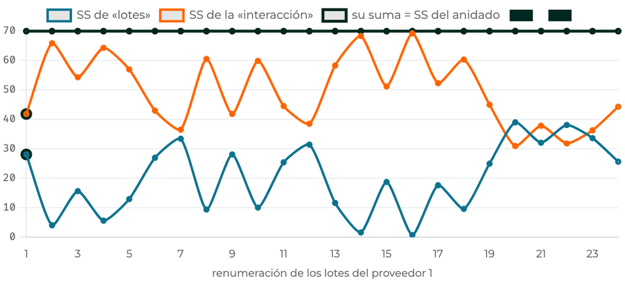

Suma de cuadrados de lotes, de la interacción y de su suma en las veinticuatro renumeraciones de los lotes del primer proveedor

Dato · cálculo del curso

Los lotes del proveedor 1, renumerados de las 24 formas posibles:

- \(SS_{AB}\), de **30.9444** a **69.1667**, y \(SS_B\) al revés: rango 38.2222
- Su suma: **69.9167** en las 24

**Interpretación.** Lo que cambia con el orden en que se anotaron los barriles no mide el proceso: no es un efecto.

Fuente: módulo 9.3 y precálculo, ejemplo 14.1; 24 permutaciones, sin azar

Capítulo 9 · Diseños anidadosDiseño de Experimentos · UnBosque24 / 42

El análisis factorial incorrecto

## El daño es interpretativo: el \(p\) de la «interacción» depende de la numeración

Dato · cálculo del curso

El \(p\) de la «interacción» va de **0.0041** a **0.1127** según la numeración, y sale significativo al 5 % en **18 de las 24**.

Interpretación

«El proveedor 2 se comporta distinto en unos lotes que en otros» supone lotes comparables entre proveedores, y no los hay: la frase suena a conclusión y no describe nada.

**Criterio del curso.** Con datos anidados se informa \(SS_{B(A)}\) con sus 9 gl; los dos trozos del factorial no se interpretan.

Fuente: módulo 9.3 (nota «Cuándo el error es inofensivo y cuándo no») y precálculo, sobre el ejemplo 14.1

Capítulo 9 · Diseños anidadosDiseño de Experimentos · UnBosque25 / 42

Idea clave · Interpretación

## Anidar es arrastrar el subíndice del padre como subíndice muerto

De ahí sale todo lo de hoy: no hay interacción, los lotes tienen \(a(b-1)\) gl, renumerar no mueve nada y \(SS_B + SS_{AB} = SS_{B(A)}\).

Capítulo 9 · Diseños anidadosDiseño de Experimentos · UnBosque26 / 42

Universidad El Bosque

Diseño de Experimentos

Capítulo 9 · Diseños anidados

Cuándo un factor está anidado

El modelo y la tabla de dos etapas

El análisis factorial incorrecto

Las esperanzas de los cuadrados medios

Elegir el denominador del F

Cierre y práctica

04

## Las esperanzas de los cuadrados medios

Un cuadrado medio no interesa por sí mismo, sino por lo que estima.

Leer en el material: 9.4 Las esperanzas de los cuadrados medios

27 / 42

Las esperanzas de los cuadrados medios

## Fijo pregunta por estos niveles; aleatorio, por la población de la que salen

### Fijo

Sus niveles son los únicos que interesan: **estos** tres proveedores. Se estiman sus efectos \(\tau_i\).

### Aleatorio

Sus niveles son una muestra: cuatro barriles de los muchos que produce cada proveedor. Se estima una varianza, \(\sigma^2_\beta\): ¿cuánto varía de barril a barril?

**Interpretación.** En el ejemplo 14.1 el proveedor es fijo y el lote, aleatorio. El ANOVA no lo sabe: la tabla de R de la sección 2 lo suponía todo fijo.

Fuente: Montgomery (2017), ejemplo 14.1, p. 621 · módulo 9.4

Capítulo 9 · Diseños anidadosDiseño de Experimentos · UnBosque28 / 42

Las esperanzas de los cuadrados medios

## Las seis reglas de §13.4 escriben cualquier esperanza sin calcularla

### 1 · El error

Lleva todos los subíndices; su componente es \(\sigma^2\).

### 2 · Los términos

Los que se suponen. Un subíndice entre paréntesis no interactúa con los del término.

### 3 · Vivos, muertos, ausentes

Fuera del paréntesis, dentro, o fuera del término.

### 4 · Grados de libertad

Niveles de los muertos por (niveles − 1) de los vivos.

### 5 · Fijo o aleatorio

\(Q[\cdot]\) o \(\sigma^2\); con algún aleatorio, la interacción es aleatoria.

### 6 · La esperanza

\(\sigma^2\), su componente y las de los términos que lo contienen sin interactuar con otro fijo.

**Dato.** Valen para factoriales, anidados y anidado-factoriales **balanceados**; el libro excluye los cuadros latinos y los bloques incompletos.

Fuente: Montgomery (2017), §13.4, pp. 602–603 · módulo 9.4

Capítulo 9 · Diseños anidadosDiseño de Experimentos · UnBosque29 / 42

Las esperanzas de los cuadrados medios

## El coeficiente de una componente: observaciones por cada valor distinto de ella

$$E(MS_T) = \sigma^2 + [\text{componente de } T] + \sum_{U \supsetneq T} [\text{componente de } U]$$

- Lotes del ejemplo 14.1: \(N/(ab) = 36/12 = 3\), de ahí \(3\sigma^2_\beta\)
- Proveedores: \(N/a = 36/3 = 12\), de ahí \(12\,Q[A]\)

Por eso \(\sigma^2\) lleva coeficiente 1 en todas: hay \(N\) valores distintos del error, y \(N/N = 1\).

Fuente: Montgomery (2017), §13.4 y Tabla 14.6 · módulo 9.4

Capítulo 9 · Diseños anidadosDiseño de Experimentos · UnBosque30 / 42

Las esperanzas de los cuadrados medios

## Las sumas de cuadrados son las mismas en las cuatro lecturas; solo cambia la esperanza

| \(A\) | \(B(A)\) | \(E(MS_A)\) | \(E(MS_{B(A)})\) |
| --- | --- | --- | --- |
| fijo | fijo | \(\sigma^2 + 12Q[A]\) | \(\sigma^2 + 3Q[B]\) |
| **fijo** | **aleatorio** | \(\sigma^2 + 12Q[A] + \mathbf{3\sigma^2_\beta}\) | \(\sigma^2 + 3\sigma^2_\beta\) |
| aleatorio | fijo | \(\sigma^2 + 12\sigma^2_\tau\) | \(\sigma^2 + 3Q[B]\) |
| aleatorio | aleatorio | \(\sigma^2 + 12\sigma^2_\tau + \mathbf{3\sigma^2_\beta}\) | \(\sigma^2 + 3\sigma^2_\beta\) |

**Interpretación.** \(3\sigma^2_\beta\) entra en la esperanza de los proveedores **solo** cuando los lotes son aleatorios. Esa línea decide el denominador del \(F\).

Fuente: algoritmo de §13.4 del módulo 9.4; coincide con la Tabla 14.1 de Montgomery (2017)

Capítulo 9 · Diseños anidadosDiseño de Experimentos · UnBosque31 / 42

Pregunta para la clase

## Acabado superficial: ¿qué esperanzas tienen \(MS_A\) y \(MS_{B(A)}\)?

Acabado superficial (problema 14.2): cuatro máquinas, tres operarios **distintos** en cada una y dos piezas por operario: \(a = 4\), \(b = 3\), \(n = 2\), \(N = 24\). Operarios aleatorios, y el capítulo supone que las máquinas también.

Respuesta

\(E(MS_A) = \sigma^2 + 2\sigma^2_\beta + 6\sigma^2_\tau\) y \(E(MS_{B(A)}) = \sigma^2 + 2\sigma^2_\beta\). Coeficientes: \(24/12 = 2\) piezas por operario y \(24/4 = 6\) por máquina.

Fuente: Montgomery (2017), problema 14.2 · módulo 9.5

Capítulo 9 · Diseños anidadosDiseño de Experimentos · UnBosque32 / 42

Universidad El Bosque

Diseño de Experimentos

Capítulo 9 · Diseños anidados

Cuándo un factor está anidado

El modelo y la tabla de dos etapas

El análisis factorial incorrecto

Las esperanzas de los cuadrados medios

Elegir el denominador del F

Cierre y práctica

05

## Elegir el denominador del F

Una prueba F compara dos cuadrados medios que, bajo la hipótesis nula, estiman lo mismo.

Leer en el material: 9.5 Elegir el denominador del F

33 / 42

Elegir el denominador del F

## El denominador es el término cuya esperanza es la del objetivo menos su propia componente

La regla del denominador

Para probar que la componente de \(T\) es nula, el denominador es el término cuya \(E(MS)\) es **la de \(T\) menos la componente de \(T\)**. Si ninguno la tiene, **no hay \(F\) exacta** y hace falta un denominador aproximado (§13.5).

Ejemplo 14.1, lotes aleatorios: \(E(MS_A) - 12Q[A] = \sigma^2 + 3\sigma^2_\beta = E(MS_{B(A)})\)

**Interpretación.** El denominador de los proveedores es \(MS_{B(A)}\), no el error: es lo que dice la Tabla 14.1 y lo que hace Minitab en la Tabla 14.6.

Fuente: Montgomery (2017), §13.4, Tablas 14.1 y 14.6 · módulo 9.5

Capítulo 9 · Diseños anidadosDiseño de Experimentos · UnBosque34 / 42

Elegir el denominador del F

## Con el denominador correcto, nada indica que los proveedores difieran: \(F = 0.969\)

Dato · ejemplo 14.1

- Proveedores contra el error, como imprime R: \(F = 7.528/2.639 = 2.853\), \(p = 0.0774\)
- Proveedores contra los lotes: \(F = 7.528/7.769 = 0.969\), \(p = 0.4158\)
- Lotes contra el error: \(F = 7.769/2.639 = 2.944\), \(p = 0.0167\)

**Interpretación.** No hay evidencia de que los proveedores difieran; los lotes sí varían. El problema no es de quién compras: es la variación de barril a barril.

Fuente: Montgomery (2017), Tabla 14.4 y p. 622; código R del módulo 9.2

Capítulo 9 · Diseños anidadosDiseño de Experimentos · UnBosque35 / 42

Elegir el denominador del F

## Acabado superficial: con los dos factores aleatorios, interesa cuánto varía cada etapa

Los dos factores aleatorios (problema 14.2)

```
aca <- data.frame(y = aca_y, A = factor(aca_maq),
                  B = factor(aca_ope))
aca_tab <- anova(aov(y ~ A/B, data = aca))
round(aca_tab[, 1:3], 4)
#>           Df Sum Sq Mean Sq
#> A          3 3617.7 1205.89
#> A:B        8 2817.7  352.21
#> Residuals 12 1014.0   84.50
```

Dato · Montgomery (2017), problema 14.2

Cuatro máquinas, tres operarios **distintos** en cada una, elegidos al azar, y dos piezas por operario.

**Criterio del curso.** El capítulo **supone** además que las máquinas son una muestra: lo que se estima es cuánta variación mete la máquina y cuánta el operario.

Fuente: Montgomery (2017), problema 14.2; código R del módulo 9.5

Capítulo 9 · Diseños anidadosDiseño de Experimentos · UnBosque36 / 42

Pregunta para la clase

## ¿Cuál es el \(F\) correcto para \(H_0\colon \sigma^2_\tau = 0\)?

\(E(MS_A) = \sigma^2 + 2\sigma^2_\beta + 6\sigma^2_\tau\), \(E(MS_{B(A)}) = \sigma^2 + 2\sigma^2_\beta\), \(E(MS_E) = \sigma^2\). Observados: **1205.8889**, **352.2083** y **84.5**.

1. \(1205.8889/84.5 = 14.2709\), con 3 y 12 gl
2. \(1205.8889/352.2083 = 3.4238\), con 3 y 8 gl
3. \(352.2083/84.5 = 4.1681\), con 8 y 12 gl
4. No hay \(F\) exacta: hace falta Satterthwaite

2 · \(F = 3.4238\), \(p = 0.0728\)

Bajo \(H_0\), \(E(MS_A) = \sigma^2 + 2\sigma^2_\beta = E(MS_{B(A)})\). La 1 es la que da un programa por defecto; la 3 prueba \(\sigma^2_\beta = 0\).

Fuente: Montgomery (2017), problema 14.2; código R del módulo 9.5

Capítulo 9 · Diseños anidadosDiseño de Experimentos · UnBosque37 / 42

Elegir el denominador del F

## Con el error de denominador, el \(F\) de las máquinas se infla: de 3.42 a 14.27

$$\frac{MS_1}{MS_2} = F_{f_1,\,f_2} \times \frac{E(MS_1)}{E(MS_2)}$$

Con la regla, bajo \(H_0\) las dos esperanzas son iguales y el cociente es una \(F\) de verdad.

Con el error, sobra \((\sigma^2 + n\sigma^2_\beta)/\sigma^2\), mayor que 1 si \(\sigma^2_\beta > 0\): un factor que nadie ve.

Dato · problema 14.2

\(1205.89/84.50 = 14.27\) con \(p = 0.000291\), frente a \(1205.89/352.21 = 3.42\) con \(p = 0.0728\).

**Interpretación.** El error suele ser el cuadrado medio más pequeño de la tabla: usarlo cuando no toca casi siempre infla el \(F\), y el \(p\) pierde su sentido.

Fuente: Montgomery (2017), problema 14.2; código R del módulo 9.5

Capítulo 9 · Diseños anidadosDiseño de Experimentos · UnBosque38 / 42

Idea clave · Criterio del curso

## El denominador se lee en las esperanzas; no se recuerda ni se coge el que está a mano

Si ninguna fila tiene la esperanza que hace falta, no hay \(F\) exacta, y se dice.

Capítulo 9 · Diseños anidadosDiseño de Experimentos · UnBosque39 / 42

Universidad El Bosque

Diseño de Experimentos

Capítulo 9 · Diseños anidados

Cuándo un factor está anidado

El modelo y la tabla de dos etapas

El análisis factorial incorrecto

Las esperanzas de los cuadrados medios

Elegir el denominador del F

Cierre y práctica

06

## Cierre y práctica

Leer en el material: 9.12 Resumen, autoevaluación y lecturas

40 / 42

Cierre y práctica

## Lo que se llevan hoy

- Un factor está anidado si sus niveles se renumeran dentro del padre sin perder nada: lo dice el protocolo
- Anidar es arrastrar un subíndice muerto: \(a(b-1)\) gl y ninguna interacción
- El factorial sobre datos anidados parte \(SS_{B(A)}\) en dos trozos sin significado
- Fijo o aleatorio no cambia las sumas de cuadrados: cambia la esperanza, y las reglas de §13.4 la escriben
- El denominador se lee: en la pureza, el \(F\) bueno de proveedores no es el que imprime R

Javier Mauricio Sierra

Capítulo 9 · Diseños anidadosDiseño de Experimentos · UnBosque41 / 42

Cierre y práctica

## Práctica en R: los husillos en clase, el propelente en casa

### En clase · EG-34 (a) a (d)

Tres máquinas, dos husillos **suyos** en cada una, cuatro piezas por husillo: husillos fijos y después aleatorios. Los componentes del (c), en la sesión 2.

### En casa · EG-33 (a) y (b)

Propelente: reproduce la renumeración de hoy y haz la tabla con el denominador correcto (datos en el módulo 9.1).

| Husillo | Máquina 1 | Máquina 2 | Máquina 3 |
| --- | --- | --- | --- |
| 1 | 12 · 9 · 11 · 12 | 14 · 15 · 13 · 14 | 14 · 10 · 12 · 11 |
| 2 | 8 · 9 · 10 · 8 | 12 · 10 · 11 · 13 | 16 · 15 · 15 · 14 |

**Criterio del curso.** Las dos tablas del EG-34, columna por columna, antes de mirar los valores \(p\).

Fuente: Montgomery (2017), problemas 14.1 y 14.3, p. 650 · módulo 9.12

Capítulo 9 · Diseños anidadosDiseño de Experimentos · UnBosque42 / 42

[output not shown]

·

00:00

A continuación

Notas